# Unit 2 (Ch. 3 - 5)

## Practice: Disequilibrium

- What is the quantity demanded at P<sub>2</sub>? Quantity supplied?
- Is there a shortage or surplus at this price? If so, how large is it?
- What is the consumer surplus?
- What is the producer surplus?
- What is the deadweight loss?

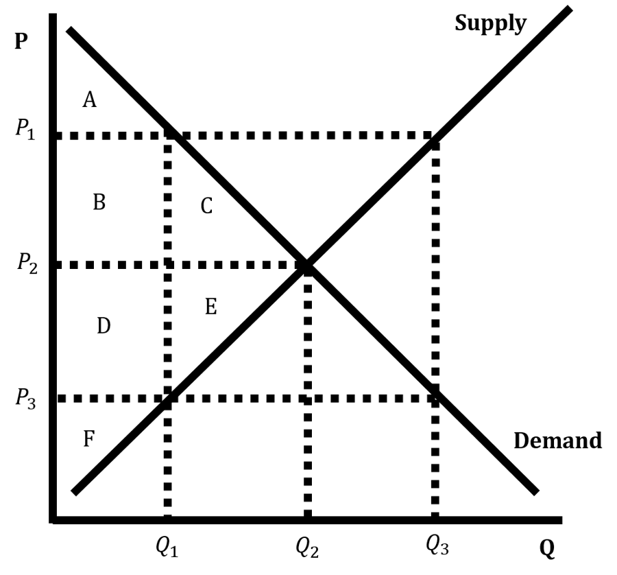

## Practice: Disequilibrium

- What is the quantity demanded at P<sub>1</sub>? Quantity supplied?
- Is there a shortage or surplus at this price? If so, how large is it?
- What is the consumer surplus?
- What is the producer surplus?
- What is the deadweight loss?
- Are consumers (producers) made better or worse off? By how much?

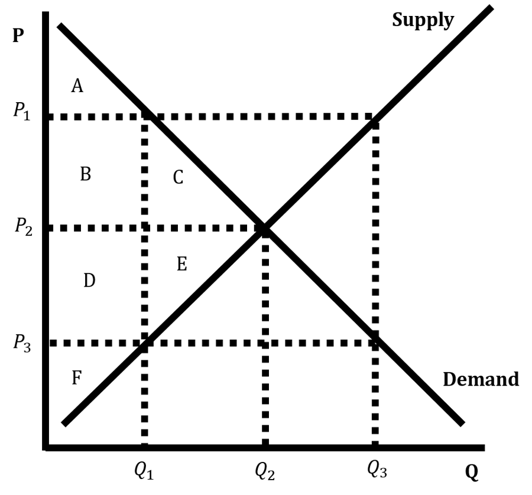

## Practice: Disequilibrium

[interactive chart not shown]

## Indirect Effects of Price Controls: Adjustment

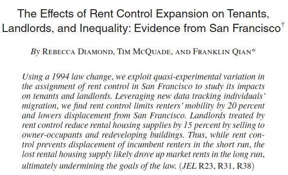

Diamond, McQuade, and Qian (2019)

## Indirect Effects of Price Controls: Adjustment

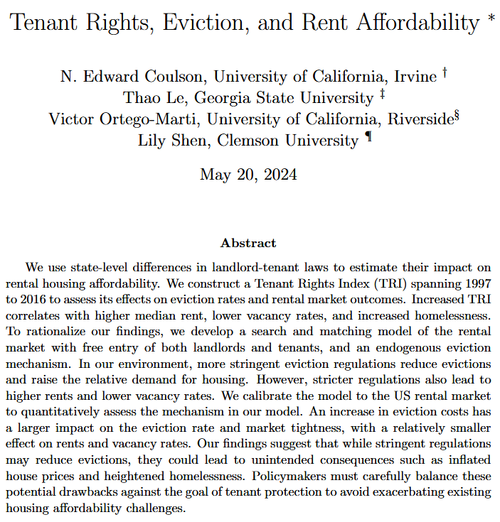

Coulson et al. (2025)

## Indirect Effects of Price Controls: Quality Declines

- “[The results]… imply that rent-controlled housing has depreciated faster than other rental housing” (Randolph 1988)
- “Rent control results in]… the deterioration and removal of dwellings from the rental stock” (Murray et al. 1991)
- “In Manhattan, we found that there was almost a 9% higher probability of an older and smaller building being in unsound condition if its units were rent controlled versus uncontrolled” (Gyourko and Linneman 1990)

## Indirect Effects of Price Controls: Black Markets

[figure not shown]

## Indirect Effects of Price Controls: Black Markets

- When binding price controls create shortages, some exchanges move outside legal markets, replacing regulated transactions with informal or illegal ones.
  - Market activity is likely to persist, but under less transparent and often riskier conditions.
- Reduced legal protections for participants
  - Example: renters paying “under the table” may have limited recourse against unsafe housing conditions.
- Increased legal risk for suppliers
  - Example: Fines, penalties, or criminal charges for violating price regulations.

## Indirect Effects of Price Controls: Black Markets

“Sex workers have historically faced harm from clients. However, sex workers have claimed that internet platforms, such as Craigslist erotic services (ERS), reduced that violence. Using the staggered rollout of ERS for identification, **we find that it is likely that ERS reduced female homicides by between 12 and 18 percent and … [sexual assault] offenses by between 7 and 9 percent**. We hypothesize that this was due to more transactions occurring indoors, better screening efforts, and more efficient matching. Our results suggest that some internet platforms may mitigate the historical risks sex workers have faced.” (Cunningham, DeAngelo, and Tripp 2024)

## Disequilibrium

### Summary

[figure not shown]

[figure not shown]

## References

Bartsch, Zachary. 2026. “Prohibition and Percolation: The Roaring Success of Coffee During US Alcohol Prohibition.” *Southern Economic Journal*.

Bernard, Louise, Andy Hackett, Robert D. Metcalfe, Luca Panzone, and Andrew Schein. 2025. “The Impact of Dynamic Prices on Electric Vehicle Public Charging Demand: Evidence from a Nationwide Natural Field Experiment.” NBER Working Paper 34600. National Bureau of Economic Research. https://doi.org/10.3386/w34600.

Burkhauser, Richard V, Drew McNichols, and Joseph J Sabia. 2025. “Minimum Wages and Poverty: New Evidence from Dynamic Difference-in-Differences Estimates.” *Review of Economics and Statistics*, 1–53.

Chamberlain, Andrew. 2016. “Jobs Created, Jobs Destroyed: What to Watch in Friday’s Jobs Report.” Glassdoor. 2016. https://www.glassdoor.com/blog/jobs-created-jobs-destroyed-what-to-watch-in-fridays-jobs-report.

Chopra, Felix, Christopher Roth, and Johannes Wohlfart. 2025. “Home Price Expectations and Spending: Evidence from a Field Experiment.” *American Economic Review* 115 (7): 2267–2305.

Clemens, Jeffrey, Olivia Edwards, and Jonathan Meer. 2025. “Did California’s Fast Food Minimum Wage Reduce Employment?” National Bureau of Economic Research.

Coulson, N Edward, Thao Le, Victor Ortego-Marti, and Lily Shen. 2025. “Tenant Rights, Eviction, and Rent Affordability.” *Journal of Urban Economics* 147: 103762.

Cunningham, Scott, Gregory DeAngelo, and John Tripp. 2024. “Did Craigslist’s Erotic Services Reduce Female Homicide and Rape?” *Journal of Human Resources* 59 (1): 280–315.

Diamond, Rebecca, Tim McQuade, and Franklin Qian. 2019. “The Effects of Rent Control Expansion on Tenants, Landlords, and Inequality: Evidence from San Francisco.” *American Economic Review* 109 (9): 3365–94.

Duranton, Gilles, and Matthew A Turner. 2011. “The Fundamental Law of Road Congestion: Evidence from US Cities.” *American Economic Review* 101 (6): 2616–52.

Goodwin, Phil B. 1996. “Empirical Evidence on Induced Traffic: A Review and Synthesis.” *Transportation* 23 (1): 35–54.

Gyourko, Joseph, and Peter Linneman. 1990. “Rent Controls and Rental Housing Quality: A Note on the Effects of New York City’s Old Controls.” *Journal of Urban Economics* 27 (3): 398–409.

Hayek, F. A. 1945. “The Use of Knowledge in Society.” *American Economic Review* 35 (4): 519–30.

Howard, Troup, Mengqi Wang, and Dayin Zhang. 2024. “Cracking down, Pricing up: Housing Supply in the Wake of Mass Deportation.” *SSRN Working Paper*.

Lordan, Grace, and David Neumark. 2018. “People Versus Machines: The Impact of Minimum Wages on Automatable Jobs.” *Labour Economics* 52: 40–53.

Murray, Michael P, C Peter Rydell, C Lance Barnett, Carol E Hillestad, and Kevin Neels. 1991. “Analyzing Rent Control: The Case of Los Angeles.” *Economic Inquiry* 29 (4): 601–25.

Randolph, William C. 1988. “Housing Depreciation and Aging Bias in the Consumer Price Index.” *Journal of Business & Economic Statistics* 6 (3): 359–71.